# Master en Data Science I

1 de Junio de 2016

## CREACIÓN DE UN SISTEMA DE CLASIFICACIÓN DOCUMENTAL

## INTRODUCCION

Más de 300 documentos de todo tipo se deben leer, clasificar y etiquetar, diariamente, por diversos departamentos. Cada nuevo proyecto en gestión genera incrementos enormes en el número de archivos (del orden de varios miles de golpe) que provocan sobrecarga/retrasos en todos los procesos cotidianos de trabajo.

Se desea acelerar/aligerar este proceso de clasificación de la documentación y automatizarlo en la medida de lo posible, al menos para aminorar la carga de trabajo y/o facilitar la vida a los diferentes departamentos.

*No existen intentos previos de solucionar este problema.*

**La propuesta es:**

"Se puede extraer suficiente información de los documentos, **ANTES** de su lectura por una persona, de manera que se facilite un tratamiento y/o extracción específicos, y acelerar así el proceso o al menos impedir los retrasos en el resto de tareas".

El contenido se encuentra repartido en carpetas de un servidor en diversos formatos de documento: DOC, DOCX, RTF y PDF.

## ADVERTENCIA

**Debido a la información confidencial contenida en los documentos, estos no se aportan a la memoria.**

En esta, exclusivamente se reseñan los hitos del proceso y el análisis efectuado con R. El proyecto consta de carpetas para los datos en carpeta *data*, reportes de salida en *reports*, código bash/python en *code*.

Entre otros, se pueden comprobar:

- iPython Notebook con analisis exploratorio (code/PRELIMINAR.ipynb)
- Resultado en HTML del iPython Notebook (reports/PRELIMINAR.html)
- Bash Script para el proceso completo y gestion de archivos (code/extraccion.sh)

Este bash script tiene parámetros obligatorios:

carpeta origen, destino, numero de procesadores, nombre del documento resumen, departamento (en este orden).

- Bash extracción resumen de datos para 1 departamento (code/resumen_juridico.sh)

## ENTORNO

Rstudio + Jupyter Notebook con Pandas y MatplotLib en cliente Windows 7. Servidor de archivos Debian Linux con pdftotext, tesseract, convert, Libre Office CLI, parallel, ImageMagick, unoconv, poppler-utils, unidoc.

```r
(.packages())

 [1] "knitr"       "gridExtra"  "ggplot2"     "party"    "strucchange"  "sandwich"     "modeltools"
 [8] "stats4"      "mvtnorm"    "grid"        "zoo"      "stats"        "graphics"     "grDevices"
[15] "utils"       "datasets"   "methods"     "base"     "wordcloud"    "RColorBrewer" "ggplot2"
[22] "tm"          "NLP"        "graphics"    "grDevices" "SnowballCC"  "biclust"      "cluster"
[29] "igraph"      "fpc"        "topicmodels" "Rcpp"     "NMF"

 # SI DESEA INSTALAR LOS PAQUETES NECESARIOS EJECUTE ESTAS 3 LINEAS
 para.instalar <- c("knitr","gridExtra","ggplot2","party","strucchange","sandwich","modeltools","fpc",
                    "stats4","mvtnorm","grid","zoo","stats","graphics","grDevices","utils","datasets",
                    "methods","base","tm","wordcloud","RColorBrewer","ggplot2","NLP","graphics",
                    "grDevices","SnowballCC","biclust","cluster","igraph","Rcpp","topicmodels","NMF")

install.packages(para.instalar, dependencies=TRUE)
install.packages("Rcampdf", repos = "http://datacube.wu.ac.at/", type = "source")
```

## ANALISIS EXPLORATORIO

En el notebook iPython adjunto (*../reports/PRELIMINAR.html*) se puede ver un analisis exploratorio de más de 32.000 archivos que los usuarios depositan en un directorio tras leerlos y etiquetarlos. Para visualizar el código se puede pulsar el botón "VER CÓDIGO" o abrir el propio código Python alojado en la carpeta *code*: (*PRELIMINAR.ipynb*).

Los datos se obtienen con un volcado del comando **ls** a CSV. Con excel operamos para quedarnos con la extension, tamaño, fecha y etiqueta que han insertado en el nombre los diferentes departamentos al clasificar. Se adjunta dicho excel procesado en la misma carpeta que esta memoria (*data/procesados.xls*):

Para ajustarse a la situación más reciente posible, obtenemos un CSV con frecuencias por tipo de documento de un día actual con documentos sin procesar.

```r
#!/bin/bash
ls | awk -F . '{print $NF}' | sort | uniq -c | awk '{print $2,$1}' > files.csv
```

## VISUALIZACIÓN DE FRECUENCIAS

```r
rm(list=ls())
```

```r
library(plyr); library(knitr)
files <- read.table("../data/files.csv", header = F)
files <- rename(files,c("V1"="type","V2"="frequency"))
files <- files[2:nrow(files),]  # elimina primera fila (el directorio)
```

```r
kable(files, format="html")
```

|  | type | frequency |
| --- | --- | --- |
| 2 | doc | 34 |
| 3 | DOC | 116 |
| 4 | pdf | 986 |
| 5 | PDF | 18 |
| 6 | rtf | 127 |
| 7 | RTF | 71 |

Nótese que la capitalización de las extensiones hace que detecte archivos del mismo formato como si fuesen distintas clases de archivo. En el notebook que analiza la carpeta de archivos ya procesados no aparece este hecho. Se tendrá en cuenta para más adelante.

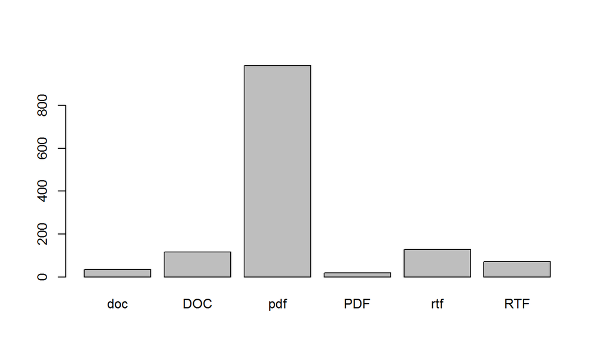

## PLANTEAMIENTO INICIAL DEL FLUJO DE TRABAJO

1. Extracción del texto de los archivos tipo DOC y RTF.
2. Extracción del texto de los documentos PDF.
3. Extracción y recuento de palabras específicas solicitadas por cada departamento.
4. Clasificación de los documentos.

## EXTRACCIÓN DE TEXTO

## RTF Y DOC

Se opta por usar la línea de comandos de LibreOffice en lugar de **catdoc** o **unrtf** (daban problemas con imágenes embebidas), que además es extremadamente más rápido que estos últimos.

El proceso es gestionado por el script de bash en el servidor (**code/extraccion.sh**). Dicho script se encarga de generar los directorios de trabajo necesarios, clasificar los documentos, abrirlos, extraer la información, obtener imágenes si existen, etcétera.

El mismo script se encarga de que todo deje registro en un log, generar tablas CSV con parámetros y metadatos de documento, llevar contabilidad para un informe final del proceso (**data/summary.log**) y medir los tiempos consumidos por cada fase.

*Se recomienda abrirlo con un editor de código para ver el proceso en detalle de manera paralela a esta memoria.*

Ejemplo de extracción de texto en archivo WORD

```r
#!/bin/bash

libreoffice --invisible --norestore --convert-to txt:"Text" --headless $word_file --outdir ${OUTPUT}"/processed"
```

## PDF

Los PDF están constituidos en ocasiones por imágenes. Siendo necesario abrirlos manualmente uno a uno para saberlo.

En caso afirmativo, para una correcta extracción del contenido, se hace necesario realizar un reconocimiento óptico de caracteres (OCR). Sin embargo, el OCR es muy costoso en tiempo y recursos. En pruebas iniciales con 400 pdf el proceso OCR tardó 3 días en completarse (1 core, 4 GB Ram).

Para analizar los PDF, mediante herramientas del sistema operativo (**poppler-utils**) se genera un CSV con metadatos de cada uno de ellos. Entre otros y sin ser exhaustivos:

- Número de imágenes (IMAGES), fuentes incrustadas (FONTS) y rotación de página (ROTATION).
- Líneas en primera página (FIRSTPAGELINES), numero total de palabras (TWORDS) y palabras en segunda página (PAGELINESSECOND).
- Frecuencia de las tres palabras más comunes en castellano según la RAE :de|la|que en primera página (FWORDS1).

[Link al corpus de la RAE](http://corpus.rae.es/lfrecuencias.html)

## Ejemplo de obtención de metadatos del PDF

En un bucle **for** que recorra todos los ficheros **$pdf_file**:

```r
#!/bin/bash

# limpiar todos los caracteres extraños con expresiones regulares
firstpage=""$(pdftotext -f 1 -l 1 -enc UTF-8 "$pdf_file" - | tr -cd \
              '[[:alnum:]][áéíóúÁÉÍÓÚñÑªºüÜ°;]\40-\040\045\054\011\012\014\015\057\050\051\100\056' \
              | sed '/^$/d' | sed 's/[^[:print:]]/ /g')

firstpagelines=""$(echo "$firstpage" | wc -l)    # líneas de primera pagina

fwords=""$(echo "$firstpage" | grep -E de\|la\|que | wc -l) # 3 mas frecuentes español

fonts=""$(pdffonts "$pdf_file" | wc -l)           # número de fuentes incrustadas

imagesp=""$(pdfimages -list "${pdf_file}" | wc -l)  # número de imágenes incrustadas
```